# Select of models

## Importación de librerias.

```python
import pandas as pd # Manipulación de datos
import matplotlib.pyplot as plt # Gráficos
import seaborn as sns # Gráficos
import warnings # Eliminar mensajes de advertencia.
import numpy as np # Operaciones matemáticas.
```

```python
warnings.filterwarnings("ignore") # Ignorar mensajes de advertencias.
```

```python
df=pd.read_csv("insurence_clear")
```

```python
df.head()
```

|  | Unnamed: 0 | age | sex | bmi | children | smoker | region | charges |
| --- | --- | --- | --- | --- | --- | --- | --- | --- |
| 0 | 1 | 18 | male | 33.77 | 1 | no | southeast | 1725.5523 |
| 1 | 2 | 28 | male | 33.00 | 3 | no | southeast | 4449.4620 |
| 2 | 10 | 25 | male | 26.22 | 0 | no | northeast | 2721.3208 |
| 3 | 12 | 23 | male | 34.40 | 0 | no | southwest | 1826.8430 |
| 4 | 15 | 19 | male | 24.60 | 1 | no | southwest | 1837.2370 |

```python
df=df.drop(["Unnamed: 0"],axis="columns")
```

#### Eliminamos columnas.

```python
df.head()
```

|  | age | sex | bmi | children | smoker | region | charges |
| --- | --- | --- | --- | --- | --- | --- | --- |
| 0 | 18 | male | 33.77 | 1 | no | southeast | 1725.5523 |
| 1 | 28 | male | 33.00 | 3 | no | southeast | 4449.4620 |
| 2 | 25 | male | 26.22 | 0 | no | northeast | 2721.3208 |
| 3 | 23 | male | 34.40 | 0 | no | southwest | 1826.8430 |
| 4 | 19 | male | 24.60 | 1 | no | southwest | 1837.2370 |

### Preprocesamiento de variables.

Los algoritmos funcionan increiblemente bien con números. Por lo cual es necesario transformar las variables tipo objeto a numérico.

### MinMaxScaler

**Fórmula:** 𝑥−𝑚𝑖𝑛(𝑥)/𝑚𝑎𝑥(𝑥)−𝑚𝑖𝑛(𝑥)

Es usado exclusivamente para varaiables numéricas. Es un reajsute de escalas. Para que las varaibles sean comparables entre si. Los datos quedan es una escala de números de 0 a 1 como máximo. Donde al valor se resta el valor mínimo a su vez se divide entre el valor máximo y se resta por el valor mínimo.

## OneHotEncoding

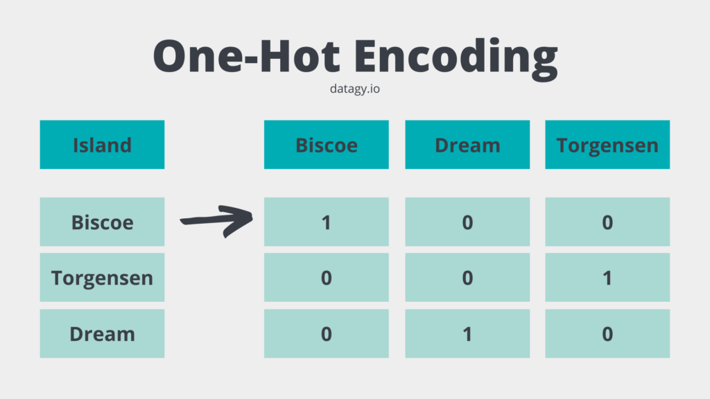

El primer método es utilizado para varaibles categóricas en la mayoria de los casos. Tiene una ventaja a nivel geométrico que la distancia entre ambas variables ficticas es igual.

```python
from sklearn.preprocessing import MinMaxScaler,OneHotEncoder,PolynomialFeatures
```

### Regresión polinomial.

Consiste en asiganarle un valor al polinonomio para que se ajsute a una relación no lineal.

Anteriormente habiamos concluido que los ususarios que no fuman. Se pueden resolver usando una regresión lineal. Pero para los fumadores no ayudaría en modelar el problema.

### Separación de inputs y outputs.

```python
def dataset():
    return df.drop(["charges"],axis="columns"),df.charges.values

X,y=dataset()
```

### División de datos de entrenamiento y validación.

```python
from sklearn.model_selection import train_test_split
```

```python
X_train,X_test,Y_train,Y_test=train_test_split(X,
                                               y,
                                               test_size=0.33,
                                               random_state=42)
```

```python
X_train.shape[0],X_test.shape[0]
```

```
(896, 442)
```

Contamos con 896 datos de entrenamiento y 442 para validación.

### Transformación polinomial.

```python
poly=PolynomialFeatures(degree=2) # Indicamos que queremos un polinomio de grado 2.
rescale=MinMaxScaler()
def poly_transform(x):

    x=pd.get_dummies(x,drop_first=True) # creación de varaibles ficticias.
    x[["age","bmi","children"]]=rescale.fit_transform(x[["age","bmi","children"]]) # Reasjuste de escalas

    return poly.fit_transform(x) # Transformación polinomial.
```

Creación de una función que nos permita realizar la transformación polinomial.

```python
X_train_poly=poly_transform(X_train)
X_test_poly=poly_transform(X_test)
```

## Creación del modelo polinomial

```python
from sklearn.linear_model import LinearRegression
```

```python
lm=LinearRegression()
```

```python
poly.fit(X_train_poly,Y_train)
```

```
PolynomialFeatures()
```

### Inicamos con el entrenamiento del modelo.

```python
lm.fit(X_train_poly,Y_train) # Pasamos los datos de entrenamiento con el método fit.
```

```
LinearRegression()
```

```python
lm.score(X_test_poly,Y_test) # Realizamos una evaluación del modelo.
```

```
0.9526906430542893
```

```python
lm.score(X_train_poly,Y_train)
```

```
0.9625148423082961
```

El módelo de regresión polinomial. Tiene un algo grado de poder explicativo. Más adelante lo compararemos con otro módelo de la familia de los ensambladores.

## Adaboost

Se refiere a una clase de algoritmos de conjuntos de aprendizaje automático donde los modelos se agregan secuencialmente y los modelos posteriores en la secuencia corrigen las predicciones realizadas por los modelos anteriores en la secuencia. Se adaptativamente a los errores de las hipótesis débiles.

## Creación del Adaboost

```python
from sklearn.tree import DecisionTreeRegressor # Importamos elñ algortimo base
from sklearn.ensemble import AdaBoostRegressor # Importamos el algoritmo
```

```python
from sklearn.compose import make_column_transformer
from sklearn.pipeline import Pipeline
```

### Transformación de los datos.

```python
tf_colummns=make_column_transformer((MinMaxScaler(),["age","bmi","children"]), # Rescaldado
                                   (OneHotEncoder(drop="if_binary"),["region","sex","smoker"]))
# OneHotEncoding
# Usamos el parámetro drop. Para sólo dejar una columna ficticia; para varaibles binarias.
```

### Error cuadrático medio.

Mide el promedio del error entre los valores originales y predichos.

```python
from sklearn.metrics import mean_squared_error
```

### Selección de la cantidad de estimadores.

Es importante seleccionar una apropiado número de árboles de decisiones. Y una buena tasa de aprendizaje apropiada. Para evitar un sobreajuste. Es decir que el modelo se adapte excesivamente a los datos de entrenamiento.

```python
def evaluate(n_trees,lr):

    estimator_list=[]
    mse_train_list=[]
    mse_test_list=[]
    # Creamos listas donde vamos a almacenar el error cuadrático medio para los datos de entrenamiento y
    # validación. Devolvera los dataos en formato dataframe para facilitar su entendimiento.
    estimators=np.arange(100,n_trees,step=1)
    for estimator in estimators:
        base=DecisionTreeRegressor(max_depth=2) # Algoritmo base
        model=AdaBoostRegressor(base_estimator=base,n_estimators=estimator,learning_rate=lr,random_state=42)
        model=Pipeline([("transform",tf_colummns),("model",model)])
        model.fit(X_train,Y_train)
        pred_train=model.predict(X_train)
        pred_test=model.predict(X_test)

        mse_train=mean_squared_error(Y_train,pred_train)
        mse_test=mean_squared_error(Y_test,pred_test)

        estimator_list.append(estimator)
        mse_test_list.append(mse_test)
        mse_train_list.append(mse_train)


    return estimator_list,mse_test_list,mse_train_list
```

Eligiremos un arbol de decisión como base. Aunque podemos seleccionar el random forest. Que es otro algoritmo de ensamble pero es más caro computacionalmente.

```python
def dataframe_evaluate_trees(n_trees,lr):
    n_trees,mse_test,mse_train=evaluate(n_trees=n_trees,lr=lr)
    #Tranformamos en formato dataframe para que sea más comprensible
    return pd.DataFrame({"n_trees":n_trees,"mse_test":mse_test,"mse_train":mse_train})
```

```python
first_evaluete=dataframe_evaluate_trees(n_trees=1000,lr=0.1)
```

```python
second_evalue=dataframe_evaluate_trees(n_trees=1000,lr=0.01)
```

```python
third_evaluate=dataframe_evaluate_trees(n_trees=1000,lr=0.001)
```

## Número de stimadores ideal.

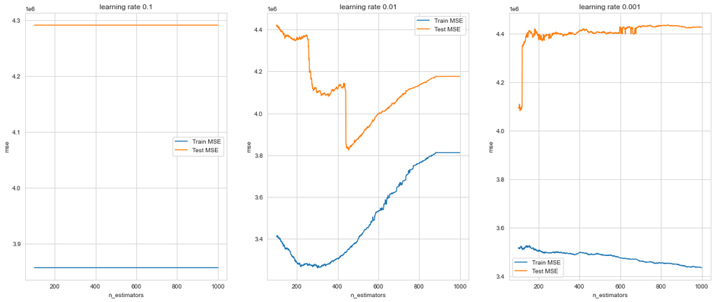

```python
sns.set_style(style="whitegrid")
fig,(ax,ax_1,ax_2)=plt.subplots(1,3,figsize=(20,8))

ax.set_title("learning rate 0.1")
ax.plot(first_evaluete["n_trees"],first_evaluete["mse_train"],label="Train MSE")
ax.plot(first_evaluete["n_trees"],first_evaluete["mse_test"],label="Test MSE")
ax.set_xlabel("n_estimators")
ax.set_ylabel("mse")

ax_1.set_title("learning rate 0.01")
ax_1.plot(second_evalue["n_trees"],second_evalue["mse_train"],label="Train MSE")
ax_1.plot(second_evalue["n_trees"],second_evalue["mse_test"],label="Test MSE")
ax_1.set_xlabel("n_estimators")
ax_1.set_ylabel("mse")

ax_2.set_title("learning rate 0.001")
ax_2.plot(third_evaluate["n_trees"],third_evaluate["mse_train"],label="Train MSE")
ax_2.plot(third_evaluate["n_trees"],third_evaluate["mse_test"],label="Test MSE")
ax_2.set_xlabel("n_estimators")
ax_2.set_ylabel("mse")

ax.legend()
ax_1.legend()
ax_2.legend()

plt.show()
```

```python
second_evalue.query("n_trees>=900 and n_trees<950")
```

|  | n_trees | mse_test | mse_train |
| --- | --- | --- | --- |
| 800 | 900 | 4.176681e+06 | 3.812905e+06 |
| 801 | 901 | 4.176681e+06 | 3.812905e+06 |
| 802 | 902 | 4.176681e+06 | 3.812905e+06 |
| 803 | 903 | 4.176681e+06 | 3.812905e+06 |
| 804 | 904 | 4.176681e+06 | 3.812905e+06 |
| 805 | 905 | 4.176681e+06 | 3.812905e+06 |
| 806 | 906 | 4.176681e+06 | 3.812905e+06 |
| 807 | 907 | 4.176681e+06 | 3.812905e+06 |
| 808 | 908 | 4.176681e+06 | 3.812905e+06 |
| 809 | 909 | 4.176681e+06 | 3.812905e+06 |
| 810 | 910 | 4.176681e+06 | 3.812905e+06 |
| 811 | 911 | 4.176681e+06 | 3.812905e+06 |
| 812 | 912 | 4.176681e+06 | 3.812905e+06 |
| 813 | 913 | 4.176681e+06 | 3.812905e+06 |
| 814 | 914 | 4.176681e+06 | 3.812905e+06 |
| 815 | 915 | 4.176681e+06 | 3.812905e+06 |
| 816 | 916 | 4.176681e+06 | 3.812905e+06 |
| 817 | 917 | 4.176681e+06 | 3.812905e+06 |
| 818 | 918 | 4.176681e+06 | 3.812905e+06 |
| 819 | 919 | 4.176681e+06 | 3.812905e+06 |
| 820 | 920 | 4.176681e+06 | 3.812905e+06 |
| 821 | 921 | 4.176681e+06 | 3.812905e+06 |
| 822 | 922 | 4.176681e+06 | 3.812905e+06 |
| 823 | 923 | 4.176681e+06 | 3.812905e+06 |
| 824 | 924 | 4.176681e+06 | 3.812905e+06 |
| 825 | 925 | 4.176681e+06 | 3.812905e+06 |
| 826 | 926 | 4.176681e+06 | 3.812905e+06 |
| 827 | 927 | 4.176681e+06 | 3.812905e+06 |
| 828 | 928 | 4.176681e+06 | 3.812905e+06 |
| 829 | 929 | 4.176681e+06 | 3.812905e+06 |
| 830 | 930 | 4.176681e+06 | 3.812905e+06 |
| 831 | 931 | 4.176681e+06 | 3.812905e+06 |
| 832 | 932 | 4.176681e+06 | 3.812905e+06 |
| 833 | 933 | 4.176681e+06 | 3.812905e+06 |
| 834 | 934 | 4.176681e+06 | 3.812905e+06 |
| 835 | 935 | 4.176681e+06 | 3.812905e+06 |
| 836 | 936 | 4.176681e+06 | 3.812905e+06 |
| 837 | 937 | 4.176681e+06 | 3.812905e+06 |
| 838 | 938 | 4.176681e+06 | 3.812905e+06 |
| 839 | 939 | 4.176681e+06 | 3.812905e+06 |
| 840 | 940 | 4.176681e+06 | 3.812905e+06 |
| 841 | 941 | 4.176681e+06 | 3.812905e+06 |
| 842 | 942 | 4.176681e+06 | 3.812905e+06 |
| 843 | 943 | 4.176681e+06 | 3.812905e+06 |
| 844 | 944 | 4.176681e+06 | 3.812905e+06 |
| 845 | 945 | 4.176681e+06 | 3.812905e+06 |
| 846 | 946 | 4.176681e+06 | 3.812905e+06 |
| 847 | 947 | 4.176681e+06 | 3.812905e+06 |
| 848 | 948 | 4.176681e+06 | 3.812905e+06 |
| 849 | 949 | 4.176681e+06 | 3.812905e+06 |

```python
second_evalue.query("n_trees>950")
```

|  | n_trees | mse_test | mse_train |
| --- | --- | --- | --- |
| 851 | 951 | 4.176681e+06 | 3.812905e+06 |
| 852 | 952 | 4.176681e+06 | 3.812905e+06 |
| 853 | 953 | 4.176681e+06 | 3.812905e+06 |
| 854 | 954 | 4.176681e+06 | 3.812905e+06 |
| 855 | 955 | 4.176681e+06 | 3.812905e+06 |
| 856 | 956 | 4.176681e+06 | 3.812905e+06 |
| 857 | 957 | 4.176681e+06 | 3.812905e+06 |
| 858 | 958 | 4.176681e+06 | 3.812905e+06 |
| 859 | 959 | 4.176681e+06 | 3.812905e+06 |
| 860 | 960 | 4.176681e+06 | 3.812905e+06 |
| 861 | 961 | 4.176681e+06 | 3.812905e+06 |
| 862 | 962 | 4.176681e+06 | 3.812905e+06 |
| 863 | 963 | 4.176681e+06 | 3.812905e+06 |
| 864 | 964 | 4.176681e+06 | 3.812905e+06 |
| 865 | 965 | 4.176681e+06 | 3.812905e+06 |
| 866 | 966 | 4.176681e+06 | 3.812905e+06 |
| 867 | 967 | 4.176681e+06 | 3.812905e+06 |
| 868 | 968 | 4.176681e+06 | 3.812905e+06 |
| 869 | 969 | 4.176681e+06 | 3.812905e+06 |
| 870 | 970 | 4.176681e+06 | 3.812905e+06 |
| 871 | 971 | 4.176681e+06 | 3.812905e+06 |
| 872 | 972 | 4.176681e+06 | 3.812905e+06 |
| 873 | 973 | 4.176681e+06 | 3.812905e+06 |
| 874 | 974 | 4.176681e+06 | 3.812905e+06 |
| 875 | 975 | 4.176681e+06 | 3.812905e+06 |
| 876 | 976 | 4.176681e+06 | 3.812905e+06 |
| 877 | 977 | 4.176681e+06 | 3.812905e+06 |
| 878 | 978 | 4.176681e+06 | 3.812905e+06 |
| 879 | 979 | 4.176681e+06 | 3.812905e+06 |
| 880 | 980 | 4.176681e+06 | 3.812905e+06 |
| 881 | 981 | 4.176681e+06 | 3.812905e+06 |
| 882 | 982 | 4.176681e+06 | 3.812905e+06 |
| 883 | 983 | 4.176681e+06 | 3.812905e+06 |
| 884 | 984 | 4.176681e+06 | 3.812905e+06 |
| 885 | 985 | 4.176681e+06 | 3.812905e+06 |
| 886 | 986 | 4.176681e+06 | 3.812905e+06 |
| 887 | 987 | 4.176681e+06 | 3.812905e+06 |
| 888 | 988 | 4.176681e+06 | 3.812905e+06 |
| 889 | 989 | 4.176681e+06 | 3.812905e+06 |
| 890 | 990 | 4.176681e+06 | 3.812905e+06 |
| 891 | 991 | 4.176681e+06 | 3.812905e+06 |
| 892 | 992 | 4.176681e+06 | 3.812905e+06 |
| 893 | 993 | 4.176681e+06 | 3.812905e+06 |
| 894 | 994 | 4.176681e+06 | 3.812905e+06 |
| 895 | 995 | 4.176681e+06 | 3.812905e+06 |
| 896 | 996 | 4.176681e+06 | 3.812905e+06 |
| 897 | 997 | 4.176681e+06 | 3.812905e+06 |
| 898 | 998 | 4.176681e+06 | 3.812905e+06 |
| 899 | 999 | 4.176681e+06 | 3.812905e+06 |

A partir de 900 árboles permance constante. Tal cual como apreciabamos en la gráfica. Por dicho motivo seleccionare 900 estimadores.

```python
base=DecisionTreeRegressor(max_depth=3)
adaboost_reg=AdaBoostRegressor(base_estimator=base,
                               n_estimators=900, #Asigamos el número de estimadores ideal.
                               learning_rate=0.01, # Asiganamos la tasa de aprendizaje.
                              random_state=42) # Estado aleatorio.
```

```python
adaboost_reg=Pipeline([('preprocess',tf_colummns),
                       ('adaboost',adaboost_reg)])
```

### Iniciamos el entrenamiento del modelo.

```python
adaboost_reg.fit(X_train,Y_train)
```

```
Pipeline(steps=[('preprocess',
                 ColumnTransformer(transformers=[('minmaxscaler',
                                                  MinMaxScaler(),
                                                  ['age', 'bmi', 'children']),
                                                 ('onehotencoder',
                                                  OneHotEncoder(drop='if_binary'),
                                                  ['region', 'sex',
                                                   'smoker'])])),
                ('adaboost',
                 AdaBoostRegressor(base_estimator=DecisionTreeRegressor(max_depth=3),
                                   learning_rate=0.01, n_estimators=900,
                                   random_state=42))])
```

```python
adaboost_reg.score(X_test,Y_test)
```

```
0.9699076121409282
```

```python
adaboost_reg.score(X_train,Y_train)
```

```
0.9717510503890445
```

Observamos que ambos modelos tiene un buen poder explicativo. Pero para llegar una mejor selección de modelo. Daremos uso a la **validación cruzada**.

### Validación cruzada.

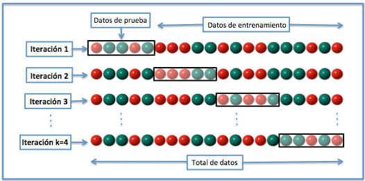

Es una técnica que consiste en hacer un submuestro de los datos. De acuerdo a la cantidad que configure el usuario. Posteriormente se sacará el porcentaje de generalización.

## Gradient Boosting.

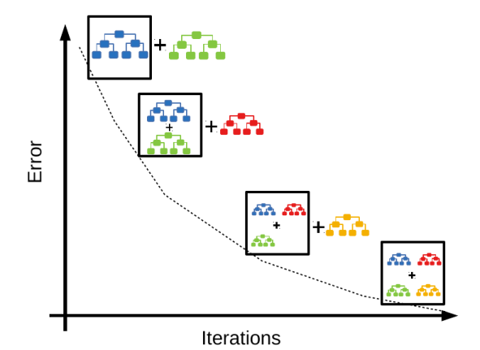

Funciona de manera similar al adaboost. De igual manera usa algoritmos más débiles. Generalmente árboles de decisión. Donde cada árbol va mejorardo según la tasa de aprendizaje. Y el resultado será el promedio de las predicciones de los algoritmos base.

## Creación del modelo.

```python
from sklearn.ensemble import GradientBoostingRegressor
```

### Selección número de estimadores Gradient Boosting

```python
def evaluate(n_trees,lr):

    estimator_list=[]
    mse_train_list=[]
    mse_test_list=[]
    # Creamos listas donde vamos a almacenar el error cuadrático medio para los datos de entrenamiento y
    # validación. Devolvera los dataos en formato dataframe para facilitar su entendimiento.
    estimators=np.arange(100,n_trees,step=1)
    for estimator in estimators:

        model=GradientBoostingRegressor(max_depth=2,n_estimators=estimator,learning_rate=lr,random_state=42)
        model=Pipeline([("transform",tf_colummns),("model",model)])
        model.fit(X_train,Y_train)
        pred_train=model.predict(X_train)
        pred_test=model.predict(X_test)

        mse_train=mean_squared_error(Y_train,pred_train)
        mse_test=mean_squared_error(Y_test,pred_test)

        estimator_list.append(estimator)
        mse_test_list.append(mse_test)
        mse_train_list.append(mse_train)


    return estimator_list,mse_test_list,mse_train_list
```

```python
first_evaluete=dataframe_evaluate_trees(n_trees=1000,lr=0.01)
```

```python
second_evaluete=dataframe_evaluate_trees(n_trees=1000,lr=0.001)
```

[figure not shown]

```python
fig,(ax,ax_1)=plt.subplots(1,2,figsize=(20,8))

ax.set_title("learning rate 0.01")
ax.plot(first_evaluete["n_trees"],first_evaluete["mse_train"],label="Train MSE")
ax.plot(first_evaluete["n_trees"],first_evaluete["mse_test"],label="Test MSE")
ax.set_xlabel("n_estimators")
ax.set_ylabel("mse")

ax_1.set_title("learning rate 0.001")
ax_1.plot(second_evalue["n_trees"],second_evalue["mse_train"],label="Train MSE")
ax_1.plot(second_evalue["n_trees"],second_evalue["mse_test"],label="Test MSE")
ax_1.set_xlabel("n_estimators")
ax_1.set_ylabel("mse")

ax.legend()
ax_1.legend()


plt.show()
```

```python
first_evaluete.query("n_trees>=600 and n_trees<=620")
```

|  | n_trees | mse_test | mse_train |
| --- | --- | --- | --- |
| 500 | 600 | 2.579719e+06 | 2.046552e+06 |
| 501 | 601 | 2.577873e+06 | 2.042532e+06 |
| 502 | 602 | 2.576836e+06 | 2.041254e+06 |
| 503 | 603 | 2.574951e+06 | 2.039829e+06 |
| 504 | 604 | 2.573982e+06 | 2.037547e+06 |
| 505 | 605 | 2.574341e+06 | 2.035886e+06 |
| 506 | 606 | 2.572509e+06 | 2.034714e+06 |
| 507 | 607 | 2.570733e+06 | 2.030791e+06 |
| 508 | 608 | 2.569724e+06 | 2.029553e+06 |
| 509 | 609 | 2.569485e+06 | 2.027326e+06 |
| 510 | 610 | 2.565604e+06 | 2.022880e+06 |
| 511 | 611 | 2.563987e+06 | 2.021735e+06 |
| 512 | 612 | 2.563759e+06 | 2.019562e+06 |
| 513 | 613 | 2.561682e+06 | 2.018301e+06 |
| 514 | 614 | 2.560127e+06 | 2.012498e+06 |
| 515 | 615 | 2.560507e+06 | 2.010920e+06 |
| 516 | 616 | 2.559540e+06 | 2.009736e+06 |
| 517 | 617 | 2.557807e+06 | 2.008632e+06 |
| 518 | 618 | 2.556909e+06 | 2.006515e+06 |
| 519 | 619 | 2.552926e+06 | 2.002214e+06 |
| 520 | 620 | 2.551986e+06 | 2.001062e+06 |

```python
gbr=GradientBoostingRegressor(max_depth=2,learning_rate=0.01,n_estimators=616,random_state=42)
gbr_pipeline=Pipeline([("transform",tf_colummns),("gbr",gbr)])
```

```python
gbr_pipeline.fit(X_train,Y_train)
```

```
Pipeline(steps=[('transform',
                 ColumnTransformer(transformers=[('minmaxscaler',
                                                  MinMaxScaler(),
                                                  ['age', 'bmi', 'children']),
                                                 ('onehotencoder',
                                                  OneHotEncoder(drop='if_binary'),
                                                  ['region', 'sex',
                                                   'smoker'])])),
                ('gbr',
                 GradientBoostingRegressor(learning_rate=0.01, max_depth=2,
                                           n_estimators=616,
                                           random_state=42))])
```

```python
gbr_pipeline.score(X_test,Y_test)
```

```
0.9815588801233216
```

```python
gbr_pipeline.score(X_train,Y_train)
```

```
0.9851103236390338
```

### Error cuadrático medio.

Consite en calcular el promedio de error. Entre los valores originales y predichos.

```python
from sklearn.metrics import mean_squared_error
```

```python
from sklearn.model_selection import cross_val_score
```

```python
def predict(model,x):

    return model.predict(x)

pred_poly_train=predict(lm,X_train_poly)
pred_poly_test=predict(lm,X_test_poly)

pred_adaboost_train=predict(adaboost_reg,X_train)
pred_adaboost_test=predict(adaboost_reg,X_test)

pred_gbr_train=predict(gbr_pipeline,X_train)
pred_gbr_test=predict(gbr_pipeline,X_test)
```

```python
def mse(y_true,y_pred):
    return mean_squared_error(y_true=y_true,y_pred=y_pred)
# Creamos una función para calcular el MSE.

mse_poly_train=mse(Y_train,pred_poly_train)
mse_poly_test=mse(Y_test,pred_poly_test)

mse_adaboost_train=mse(Y_train,pred_adaboost_train)
mse_adaboost_test=mse(Y_test,pred_adaboost_test)

mse_gbr_train=mse(Y_train,pred_gbr_train)
mse_gbr_test=mse(Y_test,pred_gbr_test)
```

### Evaluación validación cruzada.

```python
def cv_score(model,x,y):

    return cross_val_score(model,x,y,cv=10).mean() # Nos devolvera el promedio de generalización del modelo.
```

```python
cv_poly=cv_score(lm,X_test_poly,Y_test)
cv_adaboost=cv_score(adaboost_reg,X_test,Y_test)
cv_gbr=cv_score(gbr_pipeline,X_test,Y_test)
# Calculamos el promedio de la validación.
```

### Creamos una dataframe de evaluación.

```python
models_names=["Polynomial Regression","Adaboost","Gradient Boosting"]
mse_train=[mse_poly_train,mse_adaboost_train,mse_gbr_train]
mse_test=[mse_poly_test,mse_adaboost_test,mse_gbr_test]
cv=[cv_poly,cv_adaboost,cv_gbr]
```

```python
evaluate_df=pd.DataFrame({"Model":models_names,
                          "MSE train":mse_train,
                          "MSE test":mse_test,"CV":cv})
```

```python
evaluate_df
```

|  | Model | MSE train | MSE test | CV |
| --- | --- | --- | --- | --- |
| 0 | Polynomial Regression | 5.059564e+06 | 6.566314e+06 | 0.944322 |
| 1 | Adaboost | 3.812905e+06 | 4.176681e+06 | 0.970206 |
| 2 | Gradient Boosting | 2.009736e+06 | 2.559540e+06 | 0.978218 |

## Evaluación de los modelos.

```python
pred_adaboost=adaboost_reg.predict(X_test)
pred_poly=lm.predict(X_test_poly)
pred_gbr=gbr_pipeline.predict(X_test)
```

```python
df_test=pd.DataFrame({"true_values":Y_test,
                        "pred_poly":pred_poly,
                      "pred_adaboost":pred_adaboost,
                      "pred_gbr":pred_gbr,
                      "smoker":X_test["smoker"]
                     })
```

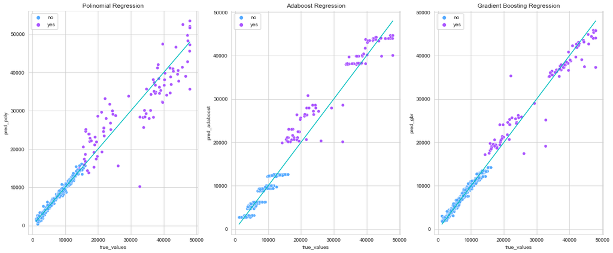

```python
fig,(ax_0,ax_1,ax_2)=plt.subplots(1,3,figsize=(20,8))
sns.set_style(style="whitegrid")

ax_0.set_title("Polinomial Regression")
sns.scatterplot(data=df_test,x="true_values",y="pred_poly",color="red",hue="smoker",ax=ax_0,palette="cool")
sns.lineplot(data=df_test,x="true_values",y="true_values",color="c",ax=ax_0)


ax_1.set_title("Adaboost Regression")
sns.scatterplot(data=df_test,x="true_values",y="pred_adaboost",color="red",hue="smoker",ax=ax_1,palette="cool")
sns.lineplot(data=df_test,x="true_values",y="true_values",color="c",ax=ax_1)

ax_2.set_title("Gradient Boosting Regression")
sns.scatterplot(data=df_test,x="true_values",y="pred_gbr",color="red",hue="smoker",ax=ax_2,palette="cool")
sns.lineplot(data=df_test,x="true_values",y="true_values",color="c",ax=ax_2)

plt.show()
```

### Conclusión.

**Regresión polinomial**

Mediante una serie de experimentos. Y probando 3 diferentes modelos de regresión. Llegue a la conclusión que el modelo polinomial es bueno para predecir para aquellos casos donde el usuario no fuma.Caso contrario dará predicciones moderadas al valor original.

**Regressión Adaboost**

Oferece mejores predicciones para los usuarios fumadores. Sin embargo para aquellos que no fuman da predicciones cercanas. Pero la regresión polinomial en dicho aspecto es superior.

**Regresión GradientBoosting**